# Data analysis- Hotel bookings

Jayesh Chaudhari

2022-06-13

### Loading libraries

```r
library(tidyverse)
library(janitor)
library(skimr)
```

### Importing .csv file into the project

```r
hotel_bookings<-read_csv("hotel_bookings.csv")
```

### Overview of first 6 rows of the dataframe

```
## # A tibble: 6 × 32
##   hotel is_canceled lead_time arrival_date_ye… arrival_date_mo… arrival_date_we…
##   <chr>       <dbl>     <dbl>            <dbl> <chr>                       <dbl>
## 1 Reso…           0       342             2015 July                           27
## 2 Reso…           0       737             2015 July                           27
## 3 Reso…           0         7             2015 July                           27
## 4 Reso…           0        13             2015 July                           27
## 5 Reso…           0        14             2015 July                           27
## 6 Reso…           0        14             2015 July                           27
## # … with 26 more variables: arrival_date_day_of_month <dbl>,
## #   stays_in_weekend_nights <dbl>, stays_in_week_nights <dbl>, adults <dbl>,
## #   children <dbl>, babies <dbl>, meal <chr>, country <chr>,
## #   market_segment <chr>, distribution_channel <chr>, is_repeated_guest <dbl>,
## #   previous_cancellations <dbl>, previous_bookings_not_canceled <dbl>,
## #   reserved_room_type <chr>, assigned_room_type <chr>, booking_changes <dbl>,
## #   deposit_type <chr>, agent <chr>, company <chr>, …
```

### Basic information about dataframe

```
## Rows: 119,390
## Columns: 32
## $ hotel                          <chr> "Resort Hotel", "Resort Hotel", "Resort…
## $ is_canceled                    <dbl> 0, 0, 0, 0, 0, 0, 0, 0, 1, 1, 1, 0, 0, …
## $ lead_time                      <dbl> 342, 737, 7, 13, 14, 14, 0, 9, 85, 75, …
## $ arrival_date_year              <dbl> 2015, 2015, 2015, 2015, 2015, 2015, 201…
## $ arrival_date_month             <chr> "July", "July", "July", "July", "July",…
## $ arrival_date_week_number       <dbl> 27, 27, 27, 27, 27, 27, 27, 27, 27, 27,…
## $ arrival_date_day_of_month      <dbl> 1, 1, 1, 1, 1, 1, 1, 1, 1, 1, 1, 1, 1, …
## $ stays_in_weekend_nights        <dbl> 0, 0, 0, 0, 0, 0, 0, 0, 0, 0, 0, 0, 0, …
## $ stays_in_week_nights           <dbl> 0, 0, 1, 1, 2, 2, 2, 2, 3, 3, 4, 4, 4, …
## $ adults                         <dbl> 2, 2, 1, 1, 2, 2, 2, 2, 2, 2, 2, 2, 2, …
## $ children                       <dbl> 0, 0, 0, 0, 0, 0, 0, 0, 0, 0, 0, 0, 0, …
## $ babies                         <dbl> 0, 0, 0, 0, 0, 0, 0, 0, 0, 0, 0, 0, 0, …
## $ meal                           <chr> "BB", "BB", "BB", "BB", "BB", "BB", "BB…
```

[output cut: 19 more lines]

### Statistics of variable: lead time

```
## [1] "Maximum lead time:  737"
```

```
## [1] "Mean of lead time:  104.01141636653"
```

### Combined(Grouped) data of hotels

```r
hotel_bookings %>%
  group_by(hotel) %>%
  summarise(average_lead_time=mean(lead_time),
            max_lead_time=max(lead_time),
            min_lead_time=min(lead_time))
```

```
## # A tibble: 2 × 4
##   hotel        average_lead_time max_lead_time min_lead_time
##   <chr>                    <dbl>         <dbl>         <dbl>
## 1 City Hotel               110.            629             0
## 2 Resort Hotel              92.7           737             0
```

### Some visual analysis and insights

#### First

1. Hypothesis: I have a hypothesis that people with children have to book in advance.

To check this we will need to plot a scattered plot of number of children v/s lead time

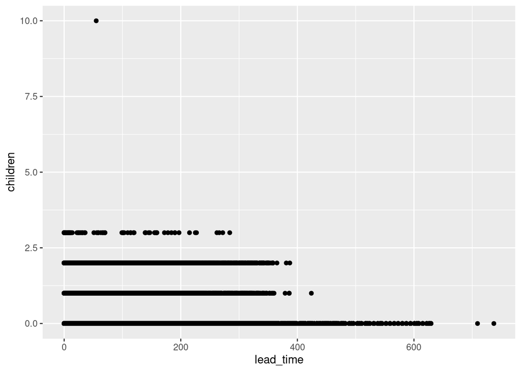

```r
ggplot(data=hotel_bookings)+
  geom_point(mapping=aes(x=lead_time, y=children))
```

Conclusion: As the number of children decrease with the increase in lead time, we can predict that more the number of children, less the lead time (booking in advance). Thus, people with children do not have to book in advance. Therefore, our hypothesis is wrong.

#### Second

2. Which group should be the target audience for weekend bookings? Children or adults?

We will plot a scattered plot- number of children v/s stays in weekend nights.

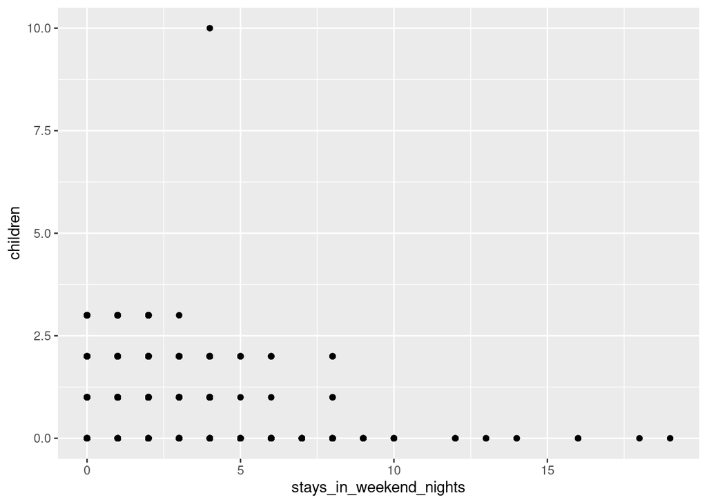

```r
ggplot(data=hotel_bookings)+
  geom_point(mapping=aes(x=stays_in_weekend_nights, y=children))
```

Conclusion: As the number of children decreases with increase in number of stays, we can assume that children do not stay longer at the weekends. Therefore, our target audience for weekend bookings should be adults.

#### Third

3. To find which distribution channel has maximum bookings and of which deposit type.

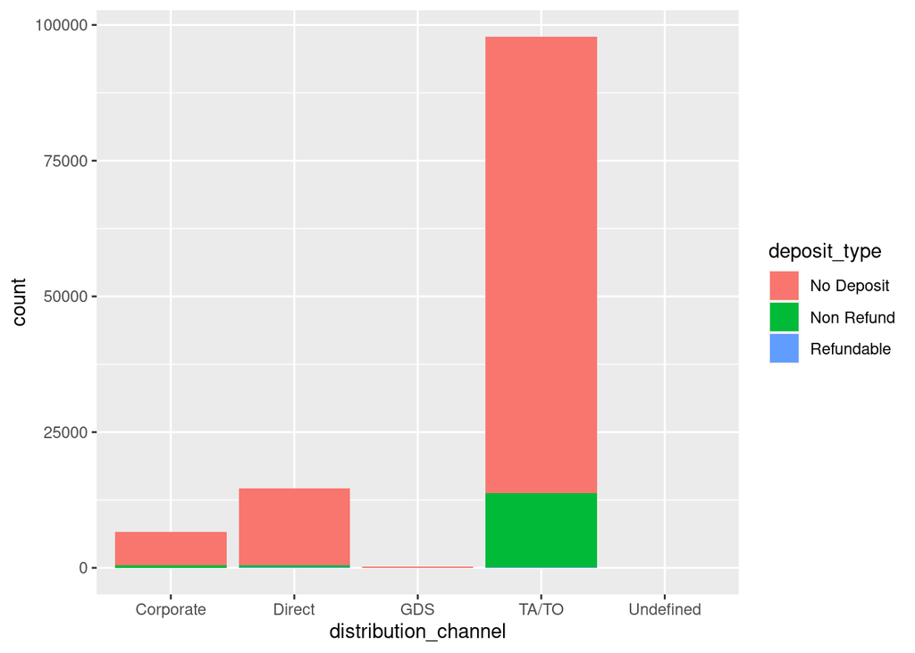

```r
ggplot(data=hotel_bookings) +
  geom_bar(mapping=aes(x=distribution_channel, fill=deposit_type))
```

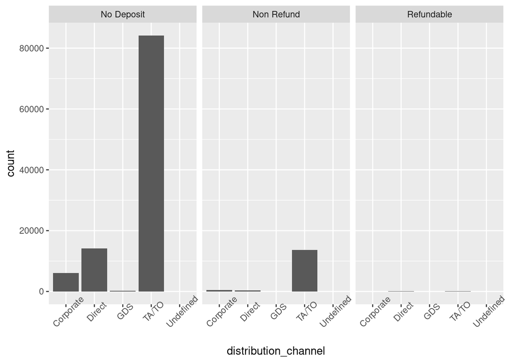

```r
ggplot(data=hotel_bookings) +
  geom_bar(mapping=aes(x=distribution_channel))+
  facet_grid(~deposit_type)+
  theme(axis.text.x = element_text(angle = 45))
```

Conclusion: We can see from both visual plots (Bar graphs) that bookings are maximum from TA/TO distribution channel when deposit type is ‘No deposit’.

Therefore, promotional campaign should be directed towards TA/TO distribution channel.

#### Fourth

4. Which market segments generate the largest number of bookings?

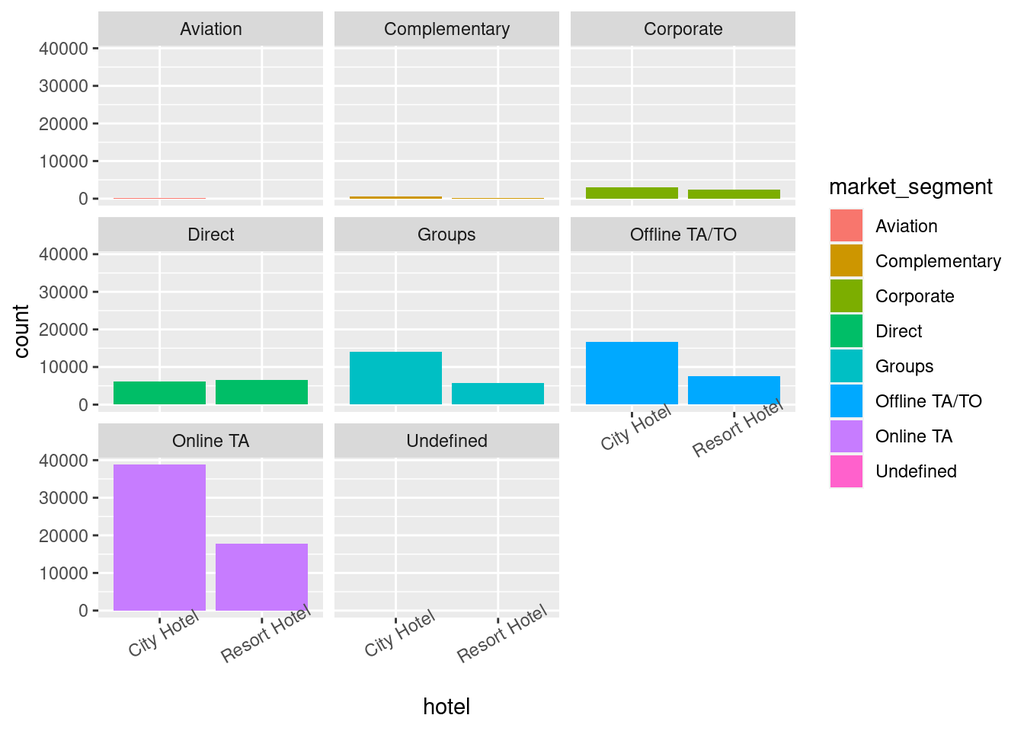

```r
ggplot(data = hotel_bookings) +
  geom_bar(mapping = aes(x = hotel, fill = market_segment))+
  facet_wrap(~market_segment)+
  theme(axis.text.x = element_text(angle = 30))
```

Conclusion: We can see that maximum booking occurs for the market segment: Online TA for the City Hotel.

Therefore, we’ll increase our promotion for Online TA market segment.

#### Fifth

###### Stakeholder’s problems are solved and analysed through statistical and visual representations in this analysis report. This report provides useful insights for promotional timing, target customers, market segment, essential distribution channels and many more.

FIN